# MTH6139 Time Series

Coursework 1 – Apple Stock Forecasting with Prophet

Amitis Kayvanfar

Spring term 2025

# Introduction

This project analyses Apple stock prices as a financial time series. The aim is to use the Prophet model in R to study the trend in the data and produce a forecast for future values.

Apple was chosen because stock prices are a common example of financial time series, and the data is easy to obtain and work with in R.

Adjusted closing price is a stock’s closing price after adjustments for events such as stock splits and dividends. Because it provides a more consistent measure of value across dates, it is frequently used when analysing share prices over time.

In this project, monthly adjusted closing prices are used so that the series is smoother and easier to interpret than daily data. In particular, monthly rather than daily closing prices are preferred because this reduces noise and irrelevant daily fluctuations, allowing the analysis to focus on the broader long-term trend and producing an overall cleaner time series.

# Data collection and preperation

## Load packages and download the data

The packages below are needed to download, prepare and model the data: `tseries` downloads apple stock price data, `zoo` helps work with dates and monthly time periods, `prophet` used to build forecasting model.

```r
library(tseries)
library(zoo)
library(prophet)
```

```r
apple <- get.hist.quote("AAPL", quote = "AdjClose")
```

```
## time series ends   2026-03-17
```

The final line downloads Apple’s adjusted closing stock price from Yahoo Finance.

## Prepare the data for Prophet

Prophet requires the data to be stored in a data frame with two columns: `ds` for the dates and `y` for the observed values.

The original Apple stock data is downloaded in daily form and converted into monthly average prices before being placed into the required format.

```r
apple_raw <- data.frame(
  date = as.Date(time(apple)),
  price = as.numeric(apple)
)

apple_raw$month <- as.yearmon(apple_raw$date)

apple_monthly <- aggregate(price ~ month, data = apple_raw, FUN = mean)

apple_df <- data.frame(
  ds = as.Date(apple_monthly$month),
  y = apple_monthly$price
)

head(apple_df)
```

```
##           ds         y
## 1 1991-01-01 0.3473615
## 2 1991-02-01 0.4146969
## 3 1991-03-01 0.4627393
## 4 1991-04-01 0.4599274
## 5 1991-05-01 0.3440773
## 6 1991-06-01 0.3119370
```

## Summary statistics

The following summary statistics give a quick overview of the Apple monthly adjusted closing price data.

```r
num_obs <- nrow(apple_df)
start_date <- min(apple_df$ds)
end_date <- max(apple_df$ds)

summary(apple_df$y)
```

```
##     Min.  1st Qu.   Median     Mean  3rd Qu.     Max.
##   0.1079   0.3375   4.2321  37.6034  34.3842 276.0481
```

```r
num_obs
```

```
## [1] 423
```

```r
start_date
```

```
## [1] "1991-01-01"
```

```r
end_date
```

```
## [1] "2026-03-01"
```

The dataset contains 423 monthly observations from 1991-01-01 to 2026-03-01. Apple’s adjusted closing price ranges from about 0.11 to 276.05 USD per share, showing substantial growth over the sample period and supporting the strong upward trend observed in the plot.

# Exploratory analysis

## Plot of the original time series

We first plot the monthly Apple stock price data so that the overall pattern can be seen.

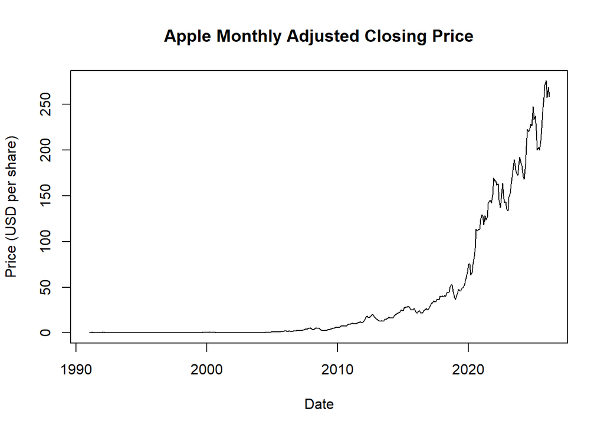

```r
plot(apple_df$ds, apple_df$y, type = "l",
     main = "Apple Monthly Adjusted Closing Price",
     xlab = "Date",
     ylab = "Price (USD per share)")
```

Key observations:

The plot shows a strong upward trend in Apple’s monthly adjusted closing price over time, with relatively slower growth in earlier years and much faster growth from around 2019 onward.

There are some fluctuations and short declines, but the overall direction remains upward. There is no clear seasonal pattern, and the fluctuations become larger as the price rises.

Apple’s strong share price growth can be linked to many factors. One important reason is the company’s success in expanding into wearables such as AirPods and the Apple Watch. Apple also introduced a 4-for-1 stock split in August 2020, which reduced the price per share and made the stock more affordable for a wider range of investors. In addition, demand for home technology increased during the COVID-19 period as more people began working from home. More recently, the growth of AI has also contributed to market optimism, with increasing interest in AI-related products and innovation.

## Log transformation of the series

A log transformation can be useful when the variability of a time series increases as the level of the series rises. Since Apple’s stock price shows larger fluctuations in later years, it is reasonable to briefly consider a log-transformed version of the series.

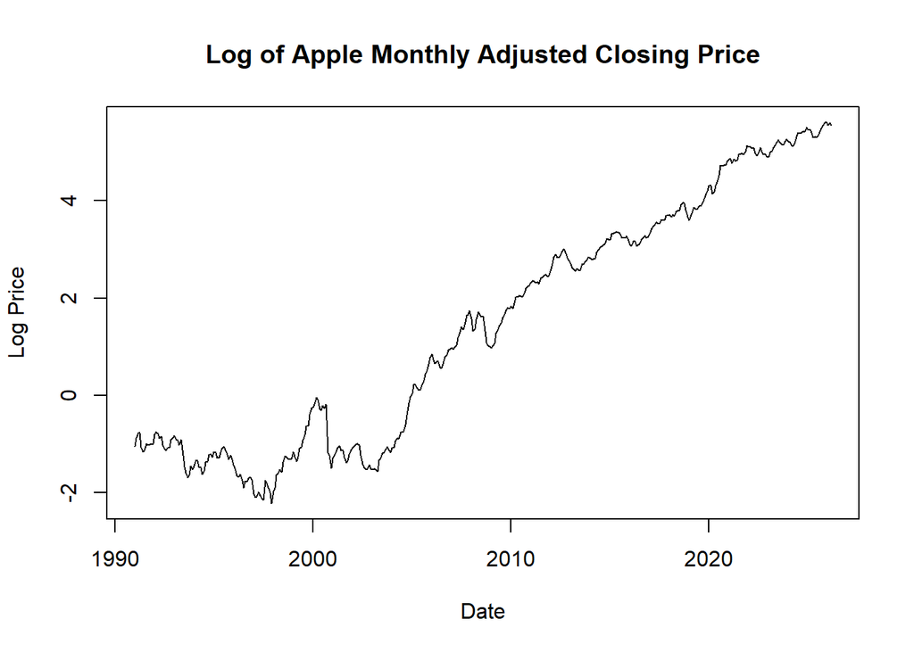

```r
apple_log <- log(apple_df$y)

plot(apple_df$ds, apple_log, type = "l",
     main = "Log of Apple Monthly Adjusted Closing Price",
     xlab = "Date",
     ylab = "Log Price")
```

The log-transformed plot appears more stable than the original series, since the fluctuations are more balanced over time and the sharp increases in later years are less extreme on the log scale.

## Fitting the Prophet model

The Prophet model is now fitted to the monthly Apple stock price data.

```r
model <- prophet(apple_df)
```

```
## Disabling weekly seasonality. Run prophet with weekly.seasonality=TRUE to override this.
```

```
## Disabling daily seasonality. Run prophet with daily.seasonality=TRUE to override this.
```

Prophet decomposes the time series into trend, seasonality, and noise, making it easier to understand the structure of the data and forecast future values.

## Forecasting future values

The next step is to create future dates and use the fitted Prophet model to generate forecasts for future values.

```r
future <- make_future_dataframe(model, periods = 12, freq = "month")
forecast <- predict(model, future)

head(forecast)
```

```
##           ds      trend additive_terms additive_terms_lower
## 1 1991-01-01 -0.9247057      0.8596335            0.8596335
## 2 1991-02-01 -0.9181947      0.7824819            0.7824819
## 3 1991-03-01 -0.9123139      1.1035492            1.1035492
## 4 1991-04-01 -0.9058029      0.1652615            0.1652615
## 5 1991-05-01 -0.8995020     -1.1986154           -1.1986154
## 6 1991-06-01 -0.8929911     -1.2522829           -1.2522829
##   additive_terms_upper     yearly yearly_lower yearly_upper
## 1            0.8596335  0.8596335    0.8596335    0.8596335
## 2            0.7824819  0.7824819    0.7824819    0.7824819
## 3            1.1035492  1.1035492    1.1035492    1.1035492
## 4            0.1652615  0.1652615    0.1652615    0.1652615
## 5           -1.1986154 -1.1986154   -1.1986154   -1.1986154
## 6           -1.2522829 -1.2522829   -1.2522829   -1.2522829
##   multiplicative_terms multiplicative_terms_lower multiplicative_terms_upper
## 1                    0                          0                          0
## 2                    0                          0                          0
## 3                    0                          0                          0
## 4                    0                          0                          0
## 5                    0                          0                          0
## 6                    0                          0                          0
##   yhat_lower yhat_upper trend_lower trend_upper        yhat
## 1 -10.063120  10.301431  -0.9247057  -0.9247057 -0.06507218
## 2 -10.176896   8.912579  -0.9181947  -0.9181947 -0.13571286
## 3  -9.639199   9.471747  -0.9123139  -0.9123139  0.19123527
## 4 -10.722792   8.516232  -0.9058029  -0.9058029 -0.74054147
## 5 -11.819666   8.606852  -0.8995020  -0.8995020 -2.09811746
## 6 -12.846571   6.676228  -0.8929911  -0.8929911 -2.14527396
```

The `forecast` data frame contains the predicted values produced by Prophet for each date, together with extra information about the model. In particular, `yhat` is the forecasted value, `yhat_lower` is the lower bound, and `yhat_upper` is the upper bound.

## Forecast Plot

The forecast plot below shows the observed data, the fitted Prophet model, and the predicted future values.

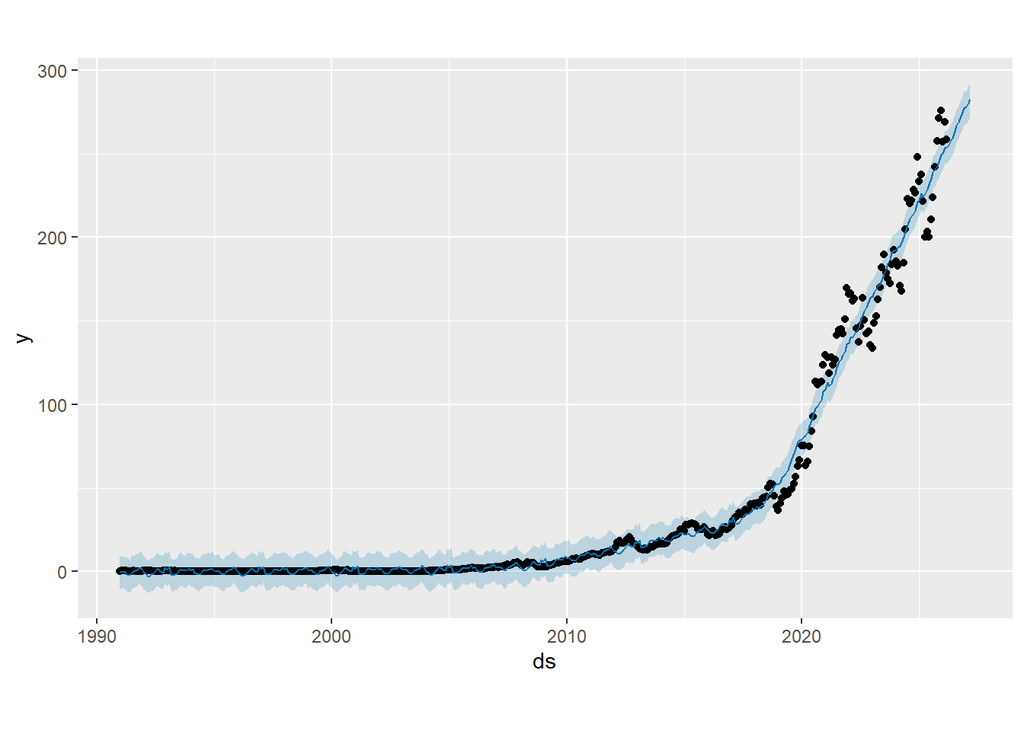

```r
plot(model, forecast)
```

The dots represent the observed data, the dark blue line shows the model prediction, and the light blue shaded band shows the uncertainty around the prediction.

## Prophet Components

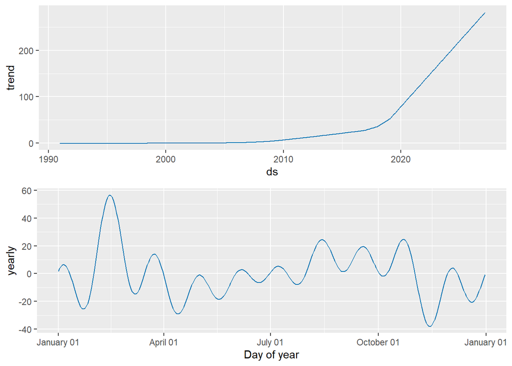

```r
prophet_plot_components(model, forecast)
```

The Prophet components plot separates the model into trend and yearly seasonality.

The trend plot shows the strong long-term upward movement in Apple’s stock price, while the yearly plot shows smaller repeating within-year patterns. Overall, the trend is the dominant feature of the series.

In this case, the trend component is much more important than the seasonal component, since the main feature of the data is the strong upward growth over time.

# Conclusion

This project analysed Apple monthly adjusted closing prices as a financial time series using Prophet in R. The data showed a clear overall upward trend over time, although there were fluctuations in some periods.

This strong long-term growth may reflect factors discussed earlier, such as Apple’s success in wearables, the 2020 stock split, increased demand for home technology during COVID-19, and more recent optimism around AI-related products.

The Prophet model was able to capture the main movement in the series and produce a short-term forecast for the next 12 months.

Overall, the results suggest that Prophet is a useful and effective tool for modelling and forecasting time series data with a strong trend.

# References

- Yahoo Finance, Apple historical stock price data and additional information: https://finance.yahoo.com
- Investopedia, adjusted closing price: https://www.investopedia.com/terms/a/adjusted_closing_price.asp
- MTH6139 Time Series lecture notes, School of Mathematical Sciences, Queen Mary University of London, Spring term 2025: https://qmplus.qmul.ac.uk/mod/resource/view.php?id=3114219